# task 2 (Lab 03 - Nobel laureates)

Adam Usama Shatadru

```r
install.packages("tidyverse")
install.packages("dplyr")
install.packages("ggplot2")
#install.packages("remotes")
#remotes::install_github("rstudio-education/dsbox")

library("tidyverse")
library("dplyr")
library("ggplot2")
#library("dsbox")
```

```r
nobel <- read_csv("data/nobel.csv")
```

In January 2017, Buzzfeed published an article on why Nobel laureates show immigration is so important for American science. You can read the article [here](https://www.buzzfeednews.com/article/peteraldhous/immigration-and-science). In the article they show that while most living Nobel laureates in the sciences are based in the US, many of them were born in other countries. This is one reason why scientific leaders say that immigration is vital for progress. In this lab we will work with the data from this article to recreate some of their visualizations as well as explore new questions.

# Exercises

## Get to know your data

1. How many observations(**answer - 935**) and how many variable(**answer - 26**)s are in the dataset? Use inline code to answer this question. What does each row represent? **answer - Each row represents one prize awarded**

26 935

There are some observations in this dataset that we will exclude from our analysis to match the Buzzfeed results.

2. Create a new data frame called `nobel_living` that filters for
- laureates for whom `country` is available
- laureates who are people as opposed to organizations (organizations are denoted with `"org"` as their `gender`)
- laureates who are still alive (their `died_date` is `NA`)

```r
nobel_living <- nobel %>%
  filter(
    !is.na(country),
    gender != "org",
    is.na(died_date)
  )
```

Confirm that once you have filtered for these characteristics you are left with a data frame with 228 observations, once again using inline code. **answer - 228 confirmed**

## Most living Nobel laureates were based in the US when they won their prizes

… says the Buzzfeed article. Let’s see if that’s true.

First, we’ll create a new variable to identify whether the laureate was in the US when they won their prize. We’ll use the `mutate()` function for this. The following pipeline mutates the `nobel_living` data frame by adding a new variable called `country_us`. We use an if statement to create this variable. The first argument in the `if_else()` function we’re using to write this if statement is the condition we’re testing for. If `country` is equal to `"USA"`, we set `country_us` to `"USA"`. If not, we set the `country_us` to `"Other"`.

```r
nobel_living <- nobel_living %>%
  mutate(
    country_us = if_else(country == "USA", "USA", "Other")
  )
```

Next, we will limit our analysis to only the following categories: Physics, Medicine, Chemistry, and Economics.

```r
nobel_living_science <- nobel_living %>%
  filter(category %in% c("Physics", "Medicine", "Chemistry", "Economics"))
```

For the next exercise work with the `nobel_living_science` data frame you created above. This means you’ll need to define this data frame in your R Markdown document, even though the next exercise doesn’t explicitly ask you to do so.

```r
#data_n_liv_sc <- as.data.frame(nobel_living_science)
```

3. Create a faceted bar plot visualizing the relationship between the category of prize and whether the laureate was in the US when they won the nobel prize. Interpret your visualization, and say a few words about whether the Buzzfeed headline is supported by the data.
   - Your visualization should be faceted by category.
   - For each facet you should have two bars, one for winners in the US and one for Other.
   - Flip the coordinates so the bars are horizontal, not vertical.

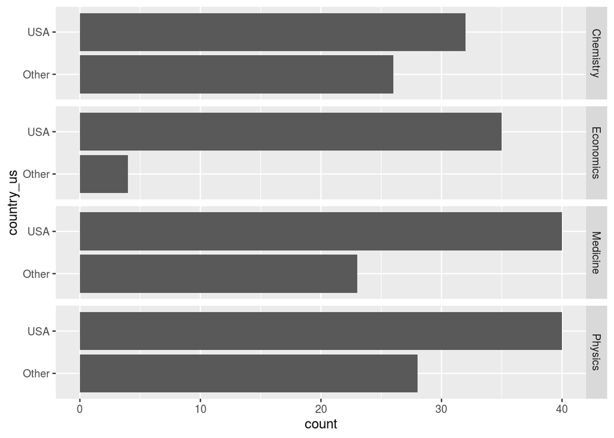

```r
t <- ggplot(nobel_living_science, aes(country_us)) + geom_bar()+ facet_grid(category ~ .) + coord_flip()
t
```

## But of those US-based Nobel laureates, many were born in other countries

4. Create a new variable called `born_country_us` that has the value `"USA"` if the laureate is born in the US, and `"Other"` otherwise.

```r
nobel_living_science <- nobel_living_science %>%
  mutate(
    born_country_us = if_else(born_country == "USA", "born USA", "born other")
  )
```

```
How many of the winners are born in the US?
```

```r
sum(nobel_living_science$born_country_us == "born USA")
```

```
## [1] 105
```

5. Add a second variable to your visualization from Exercise 3 based on whether the laureate was born in the US or not.

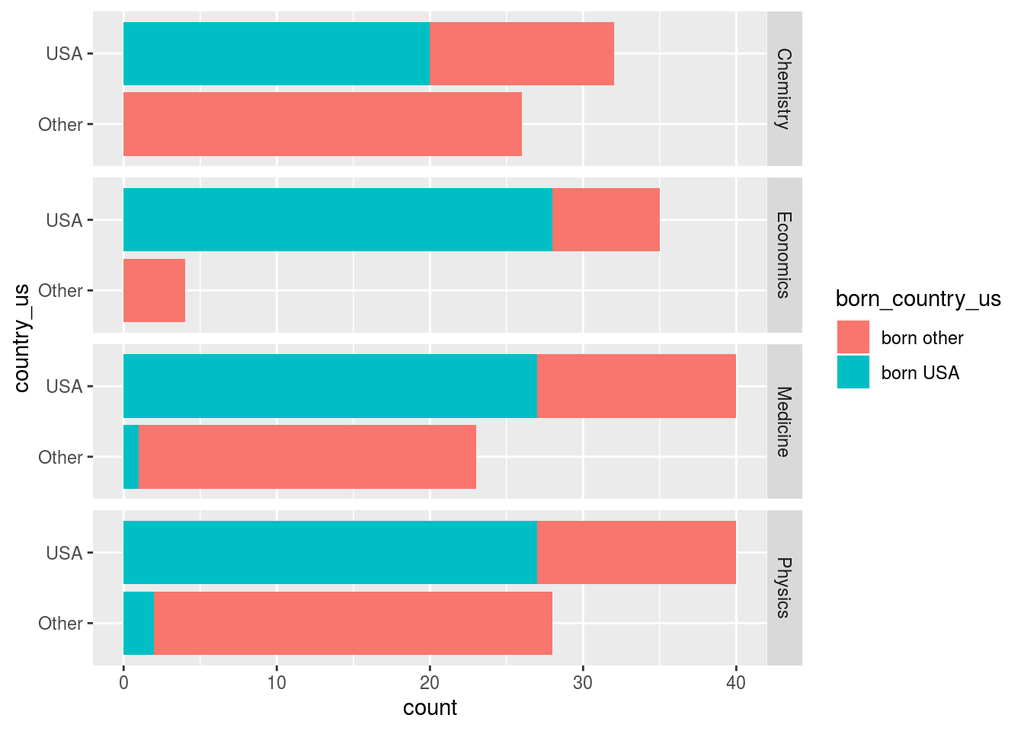

```
Based on your visualization, do the data appear to support Buzzfeed's claim?
Explain your reasoning in 1-2 sentences.
```

```r
g <- ggplot(nobel_living_science, aes(x=country_us,fill=born_country_us)) + geom_bar()+ facet_grid(category ~ .)+ coord_flip()
g
```

**answer - The claim about “importance” is relative and more general than just this data, but it is supported here. We could also say “US science is important for immigration” when considering that a significant portion of all winners born elsewhere win while based in the US**

```
-   Your final visualization should contain a facet for each category.
-   Within each facet, there should be a bar for whether the laureate won the award in the US or not.
-   Each bar should have segments for whether the laureate was born in the US or not.
```

```r
nobel_others <- nobel_living_science %>%
  filter(
    born_country != "USA",
    gender != "org",
  ) %>% count(born_country, sort=TRUE)
```